# SP26 Data Analysis

Kaylee Fernandez

2026-05-11

# Method

## Participants

19 participants completed the experiment: 10 L1 Spanish speakers and 9 L2 Spanish learners.

## Procedure

Three-phase Spanish stress-suffix association task in PsychoPy: pre-test (360 trials, 6 blocks), training (120 trials with feedback), post-test (360 trials, parallel structure). On each trial, participants heard a spoken stimulus and selected *PRESENTE* or *PASADO*.

Pre/post stimuli were drawn from six conditions varying in verb stress (paroxytone, oxytone), noun match (Match, Mismatch), and verb match (Match, Mismatch). Training stimuli were two conditions: `parox` (a) and `oxy` (b).

Table 1. Condition coding for pre- and post-test stimuli.

| Cond | Name | Verb stress | Verb match | Suffix tense | Noun match | Splice |
| --- | --- | --- | --- | --- | --- | --- |
| a | parox_nounmatch_verbmatch | paroxytone | Match | present | Match | a |
| b | oxy_nounmismatch_verbmatch | oxytone | Match | past | Mismatch | a |
| c | parox_nounmatch_verbmismatch | paroxytone | Mismatch | past | Match | a |
| d | parox_nounmismatch_verbmatch | paroxytone | Match | present | Mismatch | c |
| e | oxy_nounmatch_verbmismatch | oxytone | Mismatch | present | Match | c |
| f | oxy_nounmatch_verbmatch | oxytone | Match | past | Match | c |

Table 2. Condition coding for training stimuli.

| Cond | Name | Verb stress | Tense |
| --- | --- | --- | --- |
| a | parox | paroxytone | present |
| b | oxy | oxytone | past |

# Summary of Findings

## General Description

Accuracy and RT data from the pre- and post-test phases were analyzed using generalized linear mixed-effects models in R with the `lme4` package. Accuracy (binary correct/incorrect) was modeled with a binomial family and logit link. RT on correct trials (200–5000 ms) was modeled with a Gaussian family on the 1/RT (reciprocal/speed) transformation, selected via Box-Cox analysis (optimal λ ≈ −0.7; 95% CI [−0.8, −0.6]). Training-phase accuracy was modeled with a binomial-logit growth-curve GLMM with standardized trial number as a continuous predictor. All models included group (L1, L2), phase (pre, post), their interaction, and condition (6 levels) as fixed effects; the training model included group, trial_z, and their interaction. All categorical predictors used sum-to-zero contrasts so that coefficients represent deviations from the grand mean. Random-effects structure: by-participant intercepts and slopes for phase (or trial in the training model) and by-item intercepts. Model assumptions were assessed with the `DHARMa` package using scaled quantile residuals; QQ-plots and dispersion tests were used to evaluate fit. Statistical significance of main effects and interactions was assessed via nested model comparisons; main effects involved in interactions were tested against a no-interaction model to preserve marginality. Marginal and conditional R² were calculated following Nakagawa and Schielzeth (2013). Decision rule: α = .05.

## Results

Four follow-up analyses examined the verb-mismatch and noun-mismatch effects on accuracy and RT. The verb-match accuracy model revealed no significant interactions of group × verb match [χ²(1) = 2.82; *p* = .093], phase × verb match [χ²(1) = 0.78; *p* = .379], or group × phase × verb match [χ²(1) = 0.02; *p* = .899]. The verb-match RT model revealed significant interactions of group × verb match [χ²(1) = 9.43; *p* = .002] and phase × verb match [χ²(1) = 4.94; *p* = .026]; the three-way interaction was not significant [χ²(1) = 0.33; *p* = .565]. The noun-match models revealed no significant effects in either accuracy or RT (all *p* > .12). The verb-stress × verb-match accuracy model revealed a significant main effect of verb stress [χ²(1) = 4.89; *p* = .027] and verb match [χ²(1) = 8.54; *p* = .003]; the interaction was not significant [χ²(1) = 0.01; *p* = .930]. The verb-stress × verb-match RT model revealed significant main effects of verb stress [χ²(1) = 45.98; *p* < .001] and verb match [χ²(1) = 14.00; *p* < .001], and a significant verb-stress × verb-match interaction [χ²(1) = 4.92; *p* = .026]. The group × verb-stress × verb-match accuracy model revealed no significant effects (all *p* > .05). The group × verb-stress × verb-match RT model revealed a significant three-way interaction [χ²(1) = 15.21; *p* < .001], a significant group × verb match interaction [χ²(1) = 9.11; *p* = .003], and a significant verb-stress × verb-match interaction [χ²(1) = 4.94; *p* = .026]; the group × verb-stress interaction was not significant [χ²(1) = 2.41; *p* = .121].

# Descriptive Results

## Overview by Phase and Group

Mean accuracy and reaction time (correct, incorrect, all trials) by group and phase.

| Group | Phase | Accuracy | RT correct | RT incorrect | RT all | n incorrect | n |
| --- | --- | --- | --- | --- | --- | --- | --- |
| L1 | Pre | 97.5% | 1894 ms | 2060 ms | 1898 ms | 97 | 10 |
| L1 | Training | 77.0% | 2032 ms | 2356 ms | 2076 ms | 299 | 10 |
| L1 | Post | 93.7% | 1784 ms | 1925 ms | 1791 ms | 237 | 10 |
| L2 | Pre | 90.6% | 2273 ms | 2790 ms | 2295 ms | 303 | 9 |
| L2 | Training | 61.4% | 2392 ms | 2605 ms | 2449 ms | 417 | 9 |
| L2 | Post | 92.4% | 1958 ms | 2078 ms | 1961 ms | 245 | 9 |

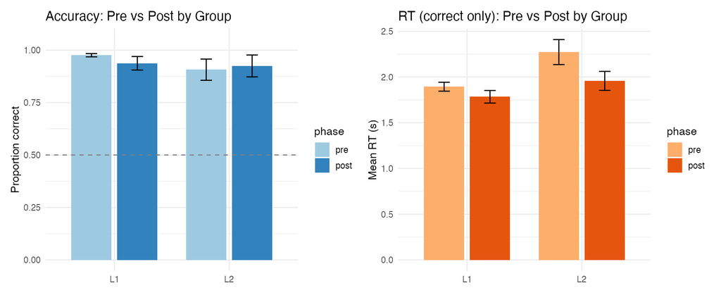

Mean accuracy (left) and reaction time on correct trials (right) for pre- and post-test phases by group. Error bars = SEM.

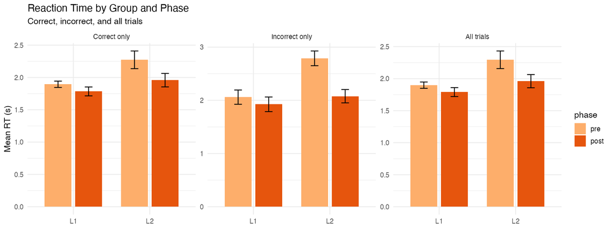

Mean reaction time at pre- and post-test by group: correct only, incorrect only, all trials.

## Performance by Condition

Accuracy and RT by group, phase, and condition.

| Group | Phase | Condition | Accuracy | RT correct | RT incorrect | RT all | n incorrect |
| --- | --- | --- | --- | --- | --- | --- | --- |
| L1 | Pre | oxy_nounmatch_verbmatch | 98.0% | 1823 ms | 2101 ms | 1831 ms | 13 |
| L1 | Pre | oxy_nounmatch_verbmismatch | 96.8% | 1893 ms | 1869 ms | 1892 ms | 21 |
| L1 | Pre | oxy_nounmismatch_verbmatch | 96.8% | 1902 ms | 2104 ms | 1910 ms | 22 |
| L1 | Pre | parox_nounmatch_verbmatch | 98.3% | 1934 ms | 1815 ms | 1933 ms | 11 |
| L1 | Pre | parox_nounmatch_verbmismatch | 97.2% | 1906 ms | 1886 ms | 1908 ms | 17 |
| L1 | Pre | parox_nounmismatch_verbmatch | 98.2% | 1906 ms | 2502 ms | 1915 ms | 13 |
| L1 | Post | oxy_nounmatch_verbmatch | 94.7% | 1703 ms | 2004 ms | 1716 ms | 33 |
| L1 | Post | oxy_nounmatch_verbmismatch | 91.9% | 1799 ms | 1630 ms | 1786 ms | 51 |
| L1 | Post | oxy_nounmismatch_verbmatch | 93.4% | 1763 ms | 1763 ms | 1782 ms | 40 |
| L1 | Post | parox_nounmatch_verbmatch | 95.0% | 1812 ms | 2019 ms | 1808 ms | 32 |
| L1 | Post | parox_nounmatch_verbmismatch | 93.2% | 1837 ms | 2156 ms | 1846 ms | 45 |
| L1 | Post | parox_nounmismatch_verbmatch | 94.0% | 1791 ms | 2207 ms | 1805 ms | 36 |
| L2 | Pre | oxy_nounmatch_verbmatch | 90.0% | 2238 ms | 2593 ms | 2262 ms | 54 |
| L2 | Pre | oxy_nounmatch_verbmismatch | 90.0% | 2203 ms | 2799 ms | 2247 ms | 54 |
| L2 | Pre | oxy_nounmismatch_verbmatch | 88.9% | 2355 ms | 2654 ms | 2360 ms | 60 |
| L2 | Pre | parox_nounmatch_verbmatch | 91.1% | 2318 ms | 2722 ms | 2343 ms | 48 |
| L2 | Pre | parox_nounmatch_verbmismatch | 91.7% | 2276 ms | 2701 ms | 2302 ms | 45 |
| L2 | Pre | parox_nounmismatch_verbmatch | 92.2% | 2225 ms | 2731 ms | 2253 ms | 42 |
| L2 | Post | oxy_nounmatch_verbmatch | 94.1% | 1930 ms | 2140 ms | 1912 ms | 32 |
| L2 | Post | oxy_nounmatch_verbmismatch | 91.9% | 1909 ms | 2016 ms | 1932 ms | 44 |
| L2 | Post | oxy_nounmismatch_verbmatch | 91.7% | 1970 ms | 2173 ms | 1950 ms | 45 |
| L2 | Post | parox_nounmatch_verbmatch | 93.3% | 1989 ms | 2578 ms | 2020 ms | 36 |
| L2 | Post | parox_nounmatch_verbmismatch | 92.2% | 2012 ms | 1580 ms | 1988 ms | 42 |
| L2 | Post | parox_nounmismatch_verbmatch | 91.5% | 1936 ms | 2140 ms | 1967 ms | 46 |

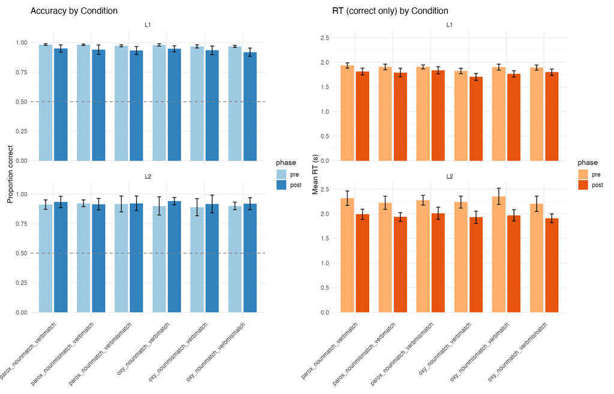

## Training Phase

Training accuracy and RT by group and condition.

| Group | Condition | Accuracy | RT correct | RT incorrect | RT all | n incorrect |
| --- | --- | --- | --- | --- | --- | --- |
| L1 | oxy | 79.8% | 1946 ms | 2259 ms | 1982 ms | 129 |
| L1 | parox | 74.2% | 2137 ms | 2403 ms | 2170 ms | 170 |
| L2 | oxy | 60.6% | 2408 ms | 2637 ms | 2461 ms | 213 |
| L2 | parox | 62.2% | 2389 ms | 2586 ms | 2440 ms | 204 |

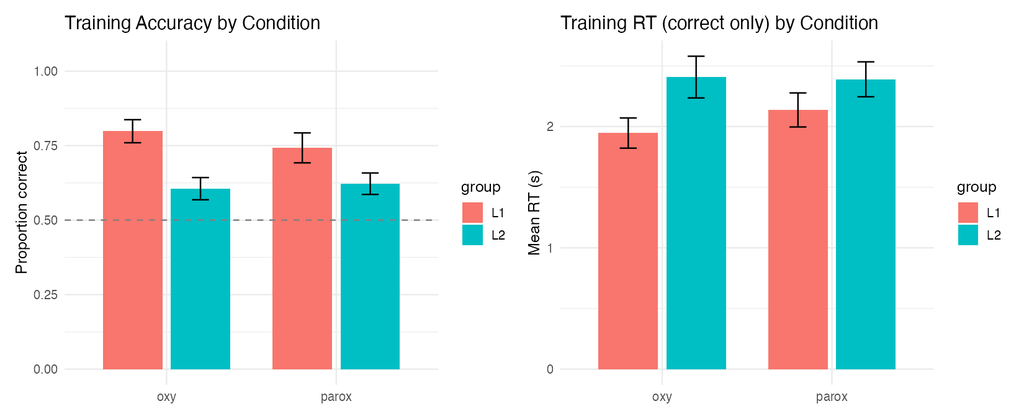

Training accuracy (left) and RT (right) by condition and group.

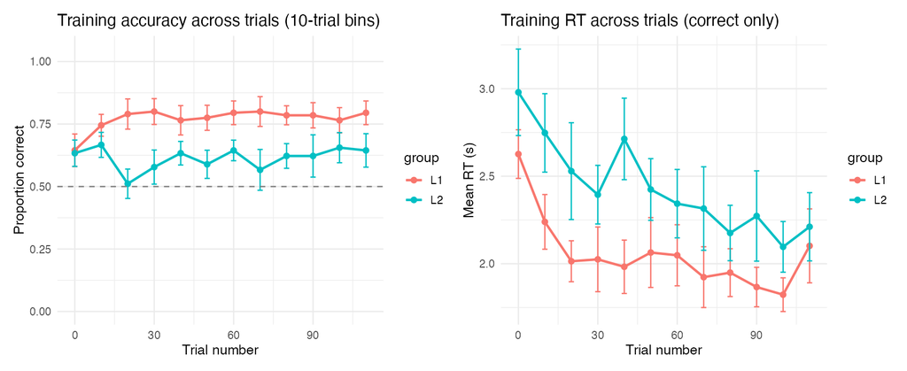

Training phase accuracy (left) and RT (right) across 10-trial bins by group.

# Statistical Analysis

Goodness of fit for each primary model.

| Model | Marginal R² | Conditional R² |
| --- | --- | --- |
| accuracy | 0.039 | 0.379 |
| rt | 0.099 | 0.323 |
| training | 0.051 | 0.186 |

## Accuracy (Pre/Post)

Accuracy model: fixed-effect estimates (log-odds scale). Condition labels: stress / N (noun match) / V (verb match), where + = Match and − = Mismatch.

| Term | β | SE | CI low | CI high | p |
| --- | --- | --- | --- | --- | --- |
| (Intercept) | 3.572 | 0.293 | 2.998 | 4.145 | 0.000 |
| group1 | 0.324 | 0.291 | -0.245 | 0.893 | 0.265 |
| phase1 | 0.000 | 0.120 | -0.236 | 0.236 | 0.999 |
| parox / N+ / V+ | 0.191 | 0.092 | 0.010 | 0.372 | 0.039 |
| parox / N− / V+ | 0.089 | 0.090 | -0.087 | 0.266 | 0.322 |
| parox / N+ / V− | -0.026 | 0.088 | -0.197 | 0.146 | 0.771 |
| oxy / N+ / V+ | 0.139 | 0.091 | -0.039 | 0.318 | 0.127 |
| oxy / N− / V+ | -0.185 | 0.085 | -0.350 | -0.019 | 0.029 |
| group1:phase1 | 0.282 | 0.120 | 0.046 | 0.518 | 0.019 |

Predicted accuracy by group and phase.

| Group | Phase | Predicted | 95% CI |
| --- | --- | --- | --- |
| L1 | pre | 98.7% | [98.7%, 98.8%] |
| L2 | pre | 95.9% | [95.8%, 96.0%] |
| L1 | post | 97.8% | [97.8%, 97.9%] |
| L2 | post | 97.6% | [97.6%, 97.7%] |

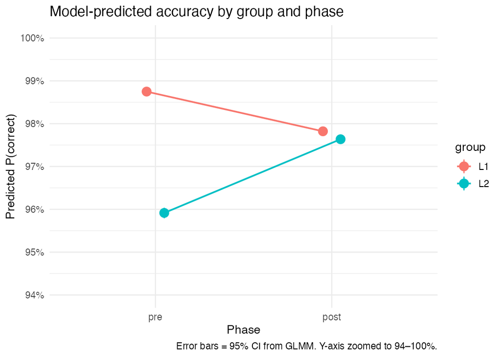

Model-predicted accuracy by group and phase.

**Effects on accuracy (NMC):**

- Group: χ²(1) = 2.94, *p* = 0.086
- Phase: χ²(1) = 0.01, *p* = 0.944
- Group × Phase: χ²(1) = 4.62, *p* = 0.032
- Condition: χ²(5) = 15.39, *p* = 0.009

## Reaction Time (Pre/Post)

RT model: fixed-effect estimates (1/RT scale; positive β = faster). Condition labels: stress / N / V, where + = Match and − = Mismatch.

| Term | β | SE | CI low | CI high | p |
| --- | --- | --- | --- | --- | --- |
| (Intercept) | 0.543 | 0.014 | 0.514 | 0.573 | 0.000 |
| group1 | 0.032 | 0.014 | 0.003 | 0.062 | 0.032 |
| phase1 | -0.027 | 0.004 | -0.036 | -0.019 | 0.000 |
| parox / N+ / V+ | -0.010 | 0.002 | -0.015 | -0.006 | 0.000 |
| parox / N− / V+ | 0.006 | 0.002 | 0.002 | 0.010 | 0.005 |
| parox / N+ / V− | -0.016 | 0.002 | -0.020 | -0.011 | 0.000 |
| oxy / N+ / V+ | 0.017 | 0.002 | 0.012 | 0.021 | 0.000 |
| oxy / N− / V+ | -0.001 | 0.002 | -0.005 | 0.004 | 0.735 |
| group1:phase1 | 0.007 | 0.004 | -0.002 | 0.016 | 0.110 |

Predicted RT by group and phase (back-transformed from 1/RT).

| Group | Phase | Predicted | 95% CI |
| --- | --- | --- | --- |
| L1 | pre | 1836 ms | [1719, 1970] |
| L2 | pre | 2145 ms | [1979, 2340] |
| L1 | post | 1707 ms | [1593, 1838] |
| L2 | post | 1869 ms | [1727, 2036] |

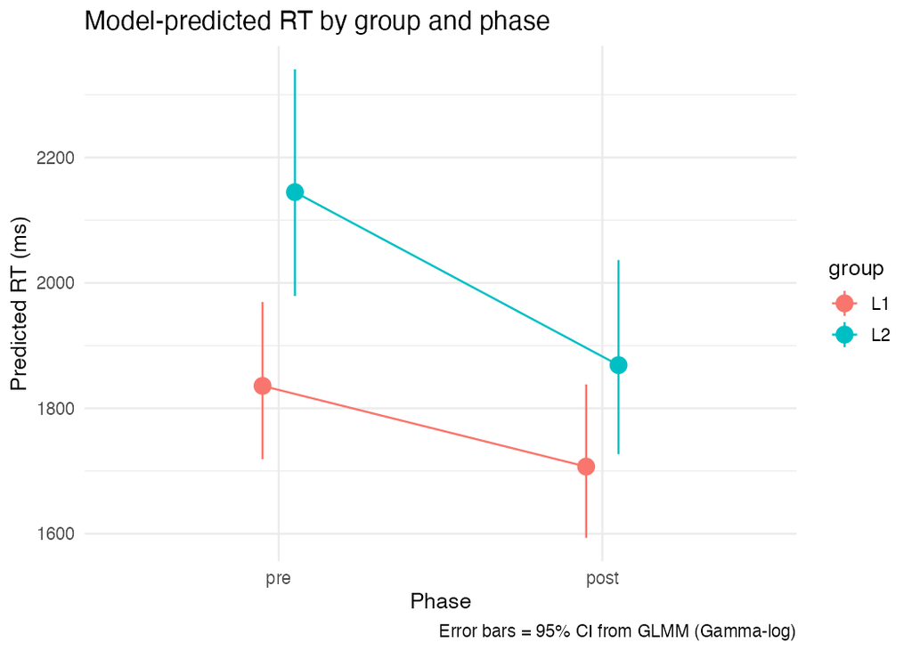

Model-predicted RT by group and phase.

**Effects on RT (NMC):**

- Group: χ²(1) = 6.27, *p* = 0.012
- Phase: χ²(1) = 22.06, *p* < .001
- Group × Phase: χ²(1) = 2.92, *p* = 0.087
- Condition: χ²(5) = 119.38, *p* < .001

**Direction:** L1 faster than L2 overall. Both groups faster at post than at pre. Condition main effect present.

## Training (Growth Curve)

Training model: fixed-effect estimates (log-odds scale).

| Term | β | SE | CI low | CI high | p |
| --- | --- | --- | --- | --- | --- |
| (Intercept) | 0.950 | 0.158 | 0.641 | 1.259 | 0.000 |
| group1 | 0.440 | 0.149 | 0.149 | 0.732 | 0.003 |
| trial_z | 0.101 | 0.057 | -0.010 | 0.213 | 0.074 |
| group1:trial_z | 0.042 | 0.056 | -0.068 | 0.152 | 0.453 |

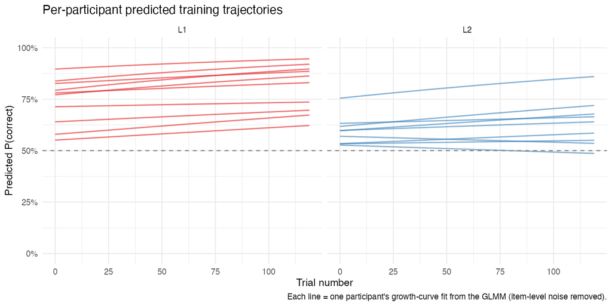

Per-participant predicted training trajectories from the growth-curve GLMM.

**Effects on training accuracy (NMC):**

- Group: χ²(1) = 6.73, *p* = 0.009
- Trial: χ²(1) = 2.86, *p* = 0.091
- Group × Trial: χ²(1) = 0.55, *p* = 0.458

**Direction:** L1 higher accuracy than L2 throughout training. Trial effect not significant. No group × trial interaction.

## Forest Plot of Primary Fixed Effects

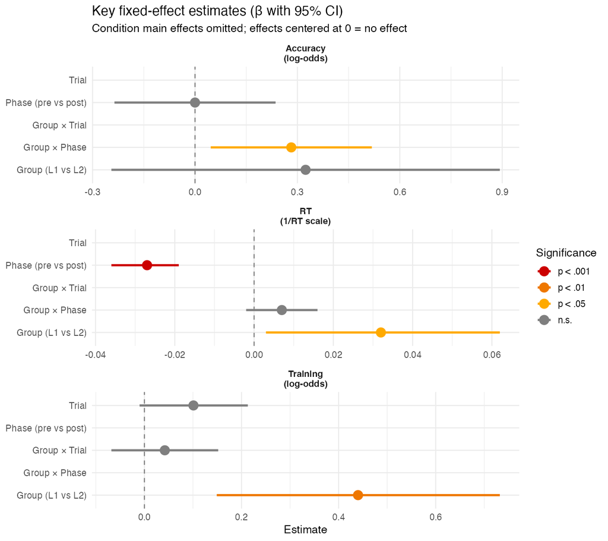

Fixed-effect estimates from the three primary models with 95% CIs. Condition main effects omitted.

# Follow-Up: Verb- and Noun-Mismatch Effects

Follow-up analyses examined the verb-mismatch and noun-mismatch effects on accuracy and RT. Four pairs of models test (a) `group × phase × verb_match`, (b) `group × phase × noun_match`, (c) `verb_stress × verb_match`, and (d) `group × verb_stress × verb_match`. Mismatch cost convention: positive cost = mismatch worse than match (= prediction surprise). RT cost = Mismatch − Match (ms); accuracy cost = Match − Mismatch (percentage points).

## Verb match × group × phase

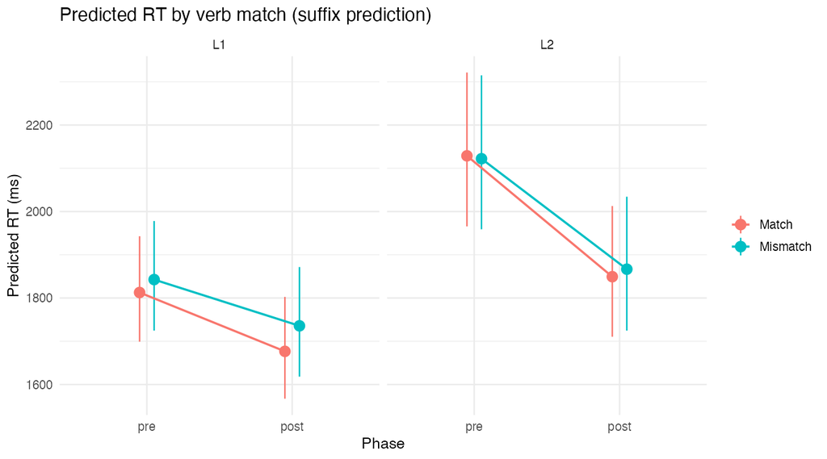

Model-predicted RT by verb match, group, and phase.

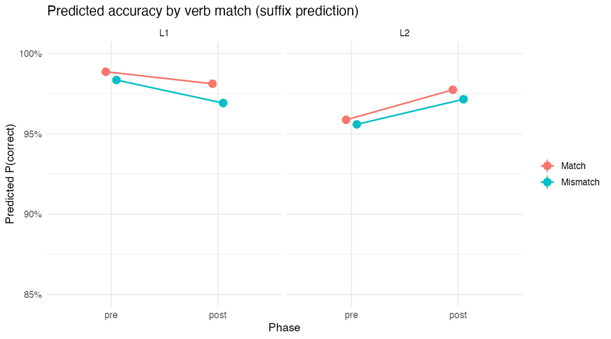

Model-predicted accuracy by verb match, group, and phase.

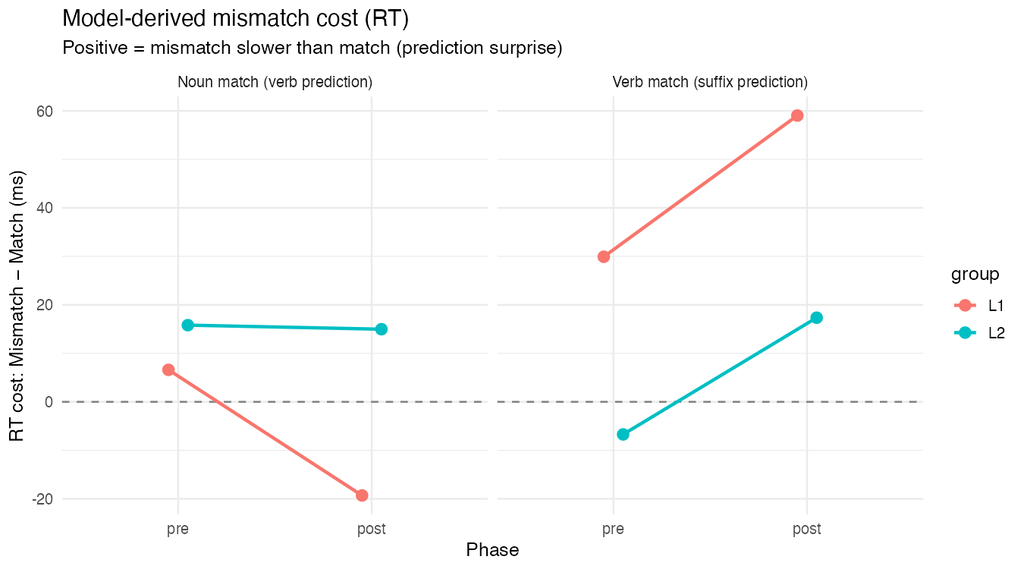

Model-derived RT mismatch cost by group and phase. Positive = mismatch slower than match.

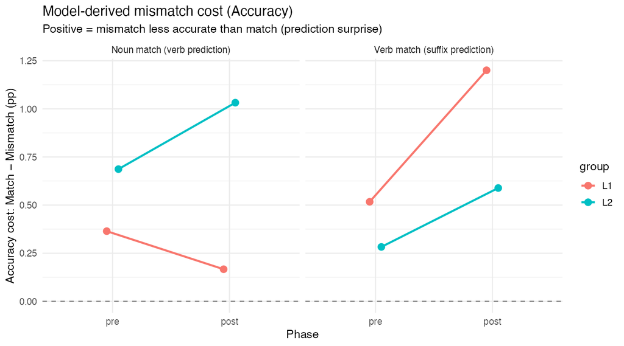

Model-derived accuracy mismatch cost by group and phase. Positive = mismatch less accurate than match.

Verb-match and noun-match: model-derived match/mismatch values and cost by group and phase.

| Factor | Measure | Group | Phase | Match | Mismatch | Cost |
| --- | --- | --- | --- | --- | --- | --- |
| Verb match (suffix prediction) | rt | L1 | pre | 1812.72 | 1842.64 | 29.92 |
| Verb match (suffix prediction) | rt | L2 | pre | 2128.80 | 2122.08 | -6.72 |
| Verb match (suffix prediction) | rt | L1 | post | 1676.63 | 1735.66 | 59.03 |
| Verb match (suffix prediction) | rt | L2 | post | 1849.30 | 1866.65 | 17.35 |
| Verb match (suffix prediction) | acc | L1 | pre | 98.87 | 98.35 | 0.52 |
| Verb match (suffix prediction) | acc | L2 | pre | 95.87 | 95.59 | 0.28 |
| Verb match (suffix prediction) | acc | L1 | post | 98.12 | 96.92 | 1.20 |
| Verb match (suffix prediction) | acc | L2 | post | 97.74 | 97.15 | 0.59 |
| Noun match (verb prediction) | rt | L1 | pre | 1810.97 | 1817.57 | 6.60 |
| Noun match (verb prediction) | rt | L2 | pre | 2108.47 | 2124.28 | 15.81 |
| Noun match (verb prediction) | rt | L1 | post | 1694.05 | 1674.74 | -19.31 |
| Noun match (verb prediction) | rt | L2 | post | 1840.43 | 1855.41 | 14.98 |
| Noun match (verb prediction) | acc | L1 | pre | 98.85 | 98.48 | 0.36 |
| Noun match (verb prediction) | acc | L2 | pre | 96.09 | 95.41 | 0.69 |
| Noun match (verb prediction) | acc | L1 | post | 97.86 | 97.69 | 0.17 |
| Noun match (verb prediction) | acc | L2 | post | 97.93 | 96.90 | 1.03 |

Verb-match: nested model comparisons.

| Model | Effect | χ² | df | p |
| --- | --- | --- | --- | --- |
| acc_verbmatch | group:phase:verb_match | 0.02 | 1 | 0.899 |
| acc_verbmatch | group:verb_match | 2.82 | 1 | 0.093 |
| acc_verbmatch | phase:verb_match | 0.78 | 1 | 0.379 |
| rt_verbmatch | group:phase:verb_match | 0.33 | 1 | 0.565 |
| rt_verbmatch | group:verb_match | 9.43 | 1 | 0.002 |
| rt_verbmatch | phase:verb_match | 4.94 | 1 | 0.026 |

**Accuracy effects (NMC):**

- Group × verb match: χ²(1) = 2.82, *p* = 0.093
- Phase × verb match: χ²(1) = 0.78, *p* = 0.379
- Group × Phase × verb match: χ²(1) = 0.02, *p* = 0.899

**RT effects (NMC):**

- Group × verb match: χ²(1) = 9.43, *p* = 0.002
- Phase × verb match: χ²(1) = 4.94, *p* = 0.026
- Group × Phase × verb match: χ²(1) = 0.33, *p* = 0.565

**Direction (RT):** L1 showed a larger verb-mismatch cost than L2 overall. Verb-mismatch cost was larger at post than at pre. The pattern of growth from pre to post was similar in both groups.

## Noun match × group × phase

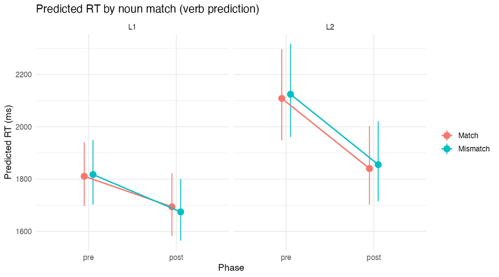

Model-predicted RT by noun match, group, and phase.

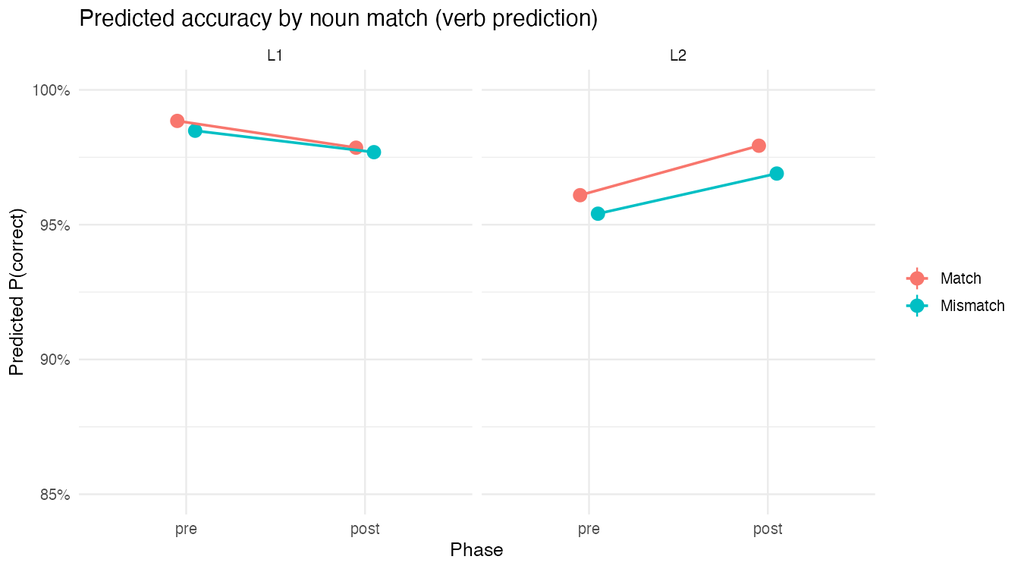

Model-predicted accuracy by noun match, group, and phase.

Noun-match: nested model comparisons.

| Model | Effect | χ² | df | p |
| --- | --- | --- | --- | --- |
| acc_nounmatch | group:phase:noun_match | 1.65 | 1 | 0.199 |
| acc_nounmatch | group:noun_match | 0.71 | 1 | 0.401 |
| acc_nounmatch | phase:noun_match | 0.13 | 1 | 0.718 |
| rt_nounmatch | group:phase:noun_match | 1.33 | 1 | 0.248 |
| rt_nounmatch | group:noun_match | 2.31 | 1 | 0.129 |
| rt_nounmatch | phase:noun_match | 1.24 | 1 | 0.266 |

**Accuracy effects (NMC):**

- Group × noun match: χ²(1) = 0.71, *p* = 0.401
- Phase × noun match: χ²(1) = 0.13, *p* = 0.718
- Group × Phase × noun match: χ²(1) = 1.65, *p* = 0.199

**RT effects (NMC):**

- Group × noun match: χ²(1) = 2.31, *p* = 0.129
- Phase × noun match: χ²(1) = 1.24, *p* = 0.266
- Group × Phase × noun match: χ²(1) = 1.33, *p* = 0.248

**Direction:** No noun-match effects reached significance in either accuracy or RT.

## Verb stress × verb match

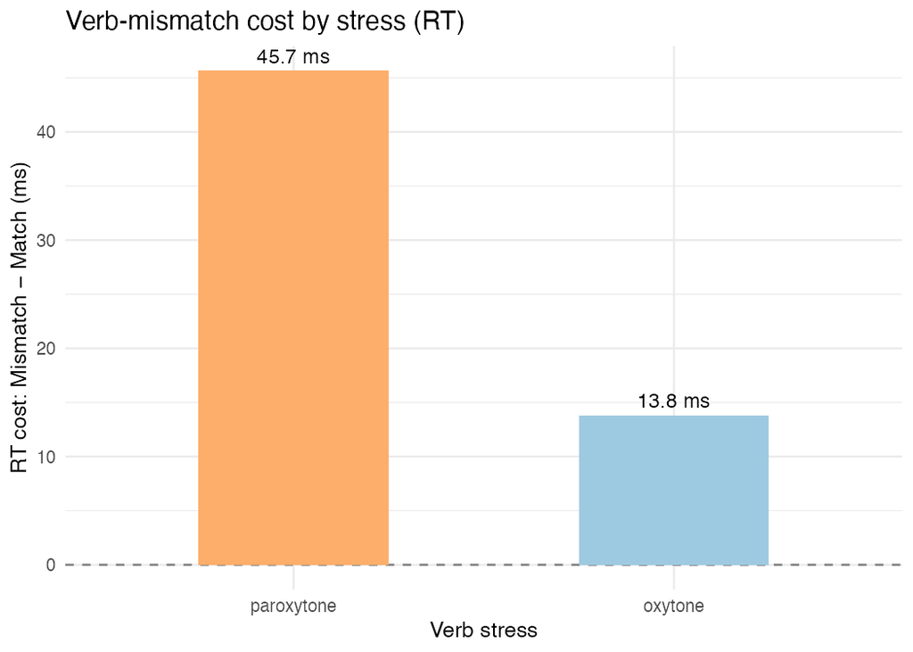

Model-derived RT verb-mismatch cost by stress type.

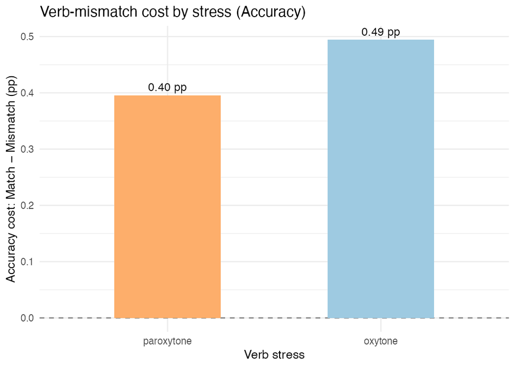

Model-derived accuracy verb-mismatch cost by stress type.

Verb stress × verb match: model-derived match/mismatch values and verb-mismatch cost by stress type.

| Factor | Measure | Stress | Match | Mismatch | Cost |
| --- | --- | --- | --- | --- | --- |
| Stress × verb_match | rt | paroxytone | 1812.88 | 1858.54 | 45.66 |
| Stress × verb_match | rt | oxytone | 1779.94 | 1793.76 | 13.82 |
| Stress × verb_match | acc | paroxytone | 98.74 | 98.35 | 0.40 |
| Stress × verb_match | acc | oxytone | 98.51 | 98.02 | 0.49 |

Verb stress × verb match: nested model comparisons.

| Model | Effect | χ² | df | p |
| --- | --- | --- | --- | --- |
| acc_stress_vm | verb_stress:verb_match | 0.01 | 1 | 0.930 |
| acc_stress_vm | verb_stress | 4.89 | 1 | 0.027 |
| acc_stress_vm | verb_match | 8.54 | 1 | 0.003 |
| rt_stress_vm | verb_stress:verb_match | 4.92 | 1 | 0.026 |
| rt_stress_vm | verb_stress | 45.98 | 1 | 0.000 |
| rt_stress_vm | verb_match | 14.00 | 1 | 0.000 |

**Accuracy effects (NMC):**

- Verb stress: χ²(1) = 4.89, *p* = 0.027
- Verb match: χ²(1) = 8.54, *p* = 0.003
- Verb stress × verb match: χ²(1) = 0.01, *p* = 0.930

**RT effects (NMC):**

- Verb stress: χ²(1) = 45.98, *p* < .001
- Verb match: χ²(1) = 14.00, *p* < .001
- Verb stress × verb match: χ²(1) = 4.92, *p* = 0.026

**Direction (RT):** Verb-mismatch cost was larger for paroxytone stimuli (~46 ms) than for oxytone stimuli (~14 ms).

## Group × verb stress × verb match

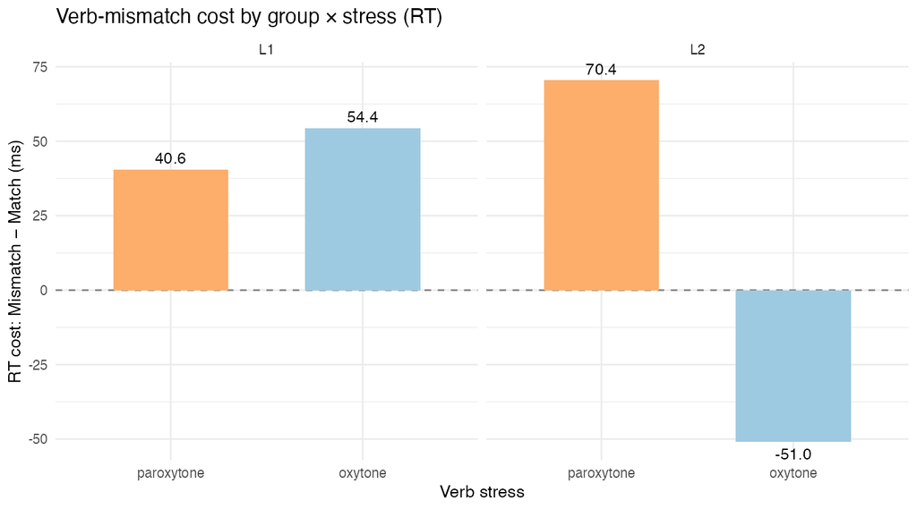

Model-derived RT verb-mismatch cost by group and stress type.

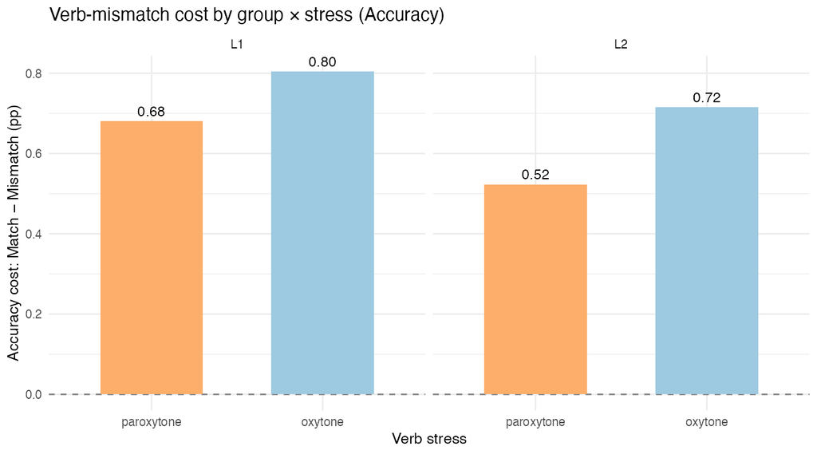

Model-derived accuracy verb-mismatch cost by group and stress type.

Group × verb stress × verb match: model-derived match/mismatch values and verb-mismatch cost by group, stress type, and measure.

| Factor | Measure | Group | Stress | Match | Mismatch | Cost |
| --- | --- | --- | --- | --- | --- | --- |
| Group × stress × verb_match | rt | L1 | paroxytone | 1819.38 | 1859.93 | 40.56 |
| Group × stress × verb_match | rt | L2 | paroxytone | 2087.54 | 2157.96 | 70.42 |
| Group × stress × verb_match | rt | L1 | oxytone | 1763.02 | 1817.47 | 54.44 |
| Group × stress × verb_match | rt | L2 | oxytone | 2084.91 | 2033.89 | -51.02 |
| Group × stress × verb_match | acc | L1 | paroxytone | 98.84 | 98.16 | 0.68 |
| Group × stress × verb_match | acc | L2 | paroxytone | 96.06 | 95.54 | 0.52 |
| Group × stress × verb_match | acc | L1 | oxytone | 98.60 | 97.80 | 0.80 |
| Group × stress × verb_match | acc | L2 | oxytone | 95.42 | 94.70 | 0.72 |

Group × verb stress × verb match: nested model comparisons.

| Model | Effect | χ² | df | p |
| --- | --- | --- | --- | --- |
| acc_g_s_vm | group:verb_stress:verb_match | 0.01 | 1 | 0.931 |
| acc_g_s_vm | group:verb_stress | 0.01 | 1 | 0.903 |
| acc_g_s_vm | group:verb_match | 3.80 | 1 | 0.051 |
| acc_g_s_vm | verb_stress:verb_match | 0.00 | 1 | 0.954 |
| rt_g_s_vm | group:verb_stress:verb_match | 15.21 | 1 | 0.000 |
| rt_g_s_vm | group:verb_stress | 2.41 | 1 | 0.121 |
| rt_g_s_vm | group:verb_match | 9.11 | 1 | 0.003 |
| rt_g_s_vm | verb_stress:verb_match | 4.94 | 1 | 0.026 |

**Accuracy effects (NMC):**

- Group × verb stress: χ²(1) = 0.01, *p* = 0.903
- Group × verb match: χ²(1) = 3.80, *p* = 0.051
- Verb stress × verb match: χ²(1) = 0.00, *p* = 0.954
- Group × verb stress × verb match: χ²(1) = 0.01, *p* = 0.931

**RT effects (NMC):**

- Group × verb stress: χ²(1) = 2.41, *p* = 0.121
- Group × verb match: χ²(1) = 9.11, *p* = 0.003
- Verb stress × verb match: χ²(1) = 4.94, *p* = 0.026
- Group × verb stress × verb match: χ²(1) = 15.21, *p* < .001

**Direction (RT):** L1 speakers showed positive verb-mismatch costs on both paroxytone (~41 ms) and oxytone (~54 ms) stimuli. L2 learners showed a positive cost on paroxytone (~70 ms) and a negative cost on oxytone (−51 ms).

# Diagnostics

DHARMa diagnostic summary. Dispersion p > .05 = adequate variance fit. KS p-values are oversensitive at large n; QQ-plots were inspected visually.

|  | Model | KS p | Dispersion | Dispersion p |
| --- | --- | --- | --- | --- |
| dispersion…1 | accuracy | 0.346 | 1.080 | 0.694 |
| dispersion…2 | rt | 0.000 | 0.949 | 0.532 |
| dispersion…3 | training | 0.316 | 1.010 | 0.880 |

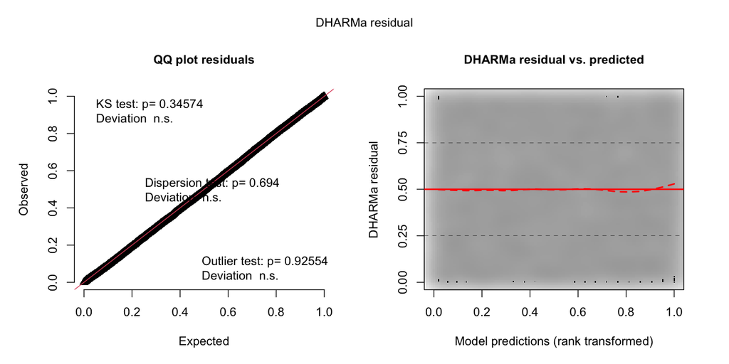

DHARMa diagnostics: accuracy model.

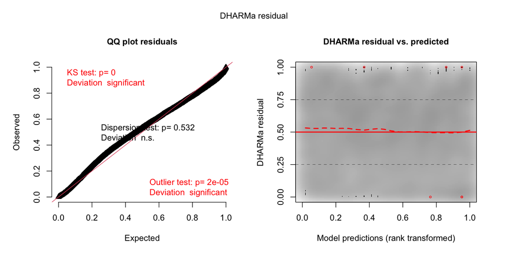

DHARMa diagnostics: RT model (1/RT scale).

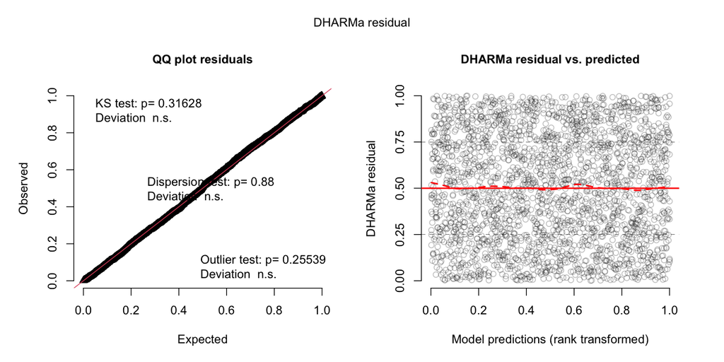

DHARMa diagnostics: training growth-curve model.

# Per-Participant Summary

Per-participant accuracy and RT by phase.

| Participant | Group | Phase | n trials | n incorrect | Accuracy | RT correct | RT incorrect | RT all |
| --- | --- | --- | --- | --- | --- | --- | --- | --- |
| 101 | L1 | Pre | 360 | 9 | 97.5% | 1807 ms | 1992 ms | 1810 ms |
| 101 | L1 | Training | 120 | 22 | 81.7% | 1808 ms | 2109 ms | 1863 ms |
| 101 | L1 | Post | 360 | 4 | 98.9% | 1681 ms | 1872 ms | 1683 ms |
| 102 | L1 | Pre | 360 | 5 | 98.6% | 2063 ms | 2774 ms | 2073 ms |
| 102 | L1 | Training | 120 | 16 | 86.7% | 1854 ms | 2191 ms | 1899 ms |
| 102 | L1 | Post | 360 | 3 | 99.2% | 1917 ms | 1827 ms | 1916 ms |
| 103 | L1 | Pre | 360 | 19 | 94.7% | 1956 ms | 2113 ms | 1964 ms |
| 103 | L1 | Training | 120 | 48 | 60.0% | 1858 ms | 1875 ms | 1865 ms |
| 103 | L1 | Post | 360 | 18 | 95.0% | 2085 ms | 2063 ms | 2083 ms |
| 104 | L1 | Pre | 360 | 29 | 91.9% | 1868 ms | 2141 ms | 1891 ms |
| 104 | L1 | Training | 120 | 53 | 55.8% | 2246 ms | 2312 ms | 2273 ms |
| 104 | L1 | Post | 360 | 36 | 90.0% | 1707 ms | 1702 ms | 1706 ms |
| 105 | L1 | Pre | 720 | 17 | 97.6% | 1911 ms | 2082 ms | 1915 ms |
| 105 | L1 | Training | 240 | 47 | 80.4% | 2108 ms | 2289 ms | 2143 ms |
| 105 | L1 | Post | 720 | 21 | 97.1% | 1958 ms | 2317 ms | 1967 ms |
| 107 | L1 | Pre | 360 | 8 | 97.8% | 1606 ms | 1490 ms | 1604 ms |
| 107 | L1 | Training | 120 | 18 | 85.0% | 1582 ms | 1976 ms | 1641 ms |
| 107 | L1 | Post | 360 | 14 | 96.1% | 1475 ms | 1357 ms | 1471 ms |
| 108 | L1 | Pre | 362 | 0 | 100.0% | 1715 ms | — | 1715 ms |
| 108 | L1 | Training | 120 | 6 | 95.0% | 1541 ms | 2258 ms | 1577 ms |
| 108 | L1 | Post | 360 | 0 | 100.0% | 1495 ms | — | 1495 ms |
| 109 | L1 | Pre | 360 | 4 | 98.9% | 1924 ms | 2086 ms | 1926 ms |
| 109 | L1 | Training | 120 | 42 | 65.0% | 2820 ms | 3200 ms | 2941 ms |
| 109 | L1 | Post | 360 | 13 | 96.4% | 2076 ms | 2756 ms | 2098 ms |
| 110 | L1 | Pre | 360 | 5 | 98.6% | 1967 ms | 1478 ms | 1960 ms |
| 110 | L1 | Training | 120 | 34 | 71.7% | 2054 ms | 2042 ms | 2051 ms |
| 110 | L1 | Post | 360 | 123 | 65.8% | 1715 ms | 1833 ms | 1756 ms |
| 111 | L1 | Pre | 360 | 1 | 99.7% | 2124 ms | 2385 ms | 2125 ms |
| 111 | L1 | Training | 120 | 13 | 89.2% | 2445 ms | 3312 ms | 2511 ms |
| 111 | L1 | Post | 360 | 5 | 98.6% | 1733 ms | 1602 ms | 1731 ms |
| 201 | L2 | Pre | 360 | 13 | 96.4% | 2135 ms | 3044 ms | 2165 ms |
| 201 | L2 | Training | 120 | 56 | 53.3% | 2374 ms | 2188 ms | 2285 ms |
| 201 | L2 | Post | 360 | 9 | 97.5% | 1889 ms | 2003 ms | 1891 ms |
| 202 | L2 | Pre | 360 | 4 | 98.9% | 1890 ms | 2792 ms | 1900 ms |
| 202 | L2 | Training | 120 | 21 | 82.5% | 2138 ms | 3147 ms | 2288 ms |
| 202 | L2 | Post | 360 | 8 | 97.8% | 1846 ms | 2028 ms | 1849 ms |
| 203 | L2 | Pre | 360 | 22 | 93.9% | 1888 ms | 2198 ms | 1906 ms |
| 203 | L2 | Training | 120 | 44 | 63.3% | 1702 ms | 1868 ms | 1763 ms |
| 203 | L2 | Post | 360 | 4 | 98.9% | 1650 ms | 1467 ms | 1648 ms |
| 204 | L2 | Pre | 360 | 42 | 88.3% | 2105 ms | 2472 ms | 2147 ms |
| 204 | L2 | Training | 120 | 54 | 55.0% | 2387 ms | 2668 ms | 2512 ms |
| 204 | L2 | Post | 360 | 19 | 94.7% | 1943 ms | 2335 ms | 1964 ms |
| 205 | L2 | Pre | 360 | 9 | 97.5% | 2266 ms | 2615 ms | 2274 ms |
| 205 | L2 | Training | 120 | 40 | 66.7% | 2765 ms | 2901 ms | 2808 ms |
| 205 | L2 | Post | 360 | 2 | 99.4% | 2048 ms | 1961 ms | 2047 ms |
| 206 | L2 | Pre | 360 | 9 | 97.5% | 2315 ms | 2428 ms | 2318 ms |
| 206 | L2 | Training | 120 | 54 | 55.0% | 3106 ms | 3145 ms | 3123 ms |
| 206 | L2 | Post | 360 | 11 | 96.9% | 1889 ms | 1883 ms | 1889 ms |
| 207 | L2 | Pre | 360 | 176 | 51.1% | 3221 ms | 3284 ms | 3251 ms |
| 207 | L2 | Training | 120 | 46 | 61.7% | 2339 ms | 2544 ms | 2420 ms |
| 207 | L2 | Post | 360 | 177 | 50.8% | 2711 ms | 2697 ms | 2704 ms |
| 208 | L2 | Pre | 360 | 20 | 94.4% | 2095 ms | 2805 ms | 2131 ms |
| 208 | L2 | Training | 120 | 60 | 50.0% | 1921 ms | 2155 ms | 2036 ms |
| 208 | L2 | Post | 360 | 10 | 97.2% | 1665 ms | 1821 ms | 1669 ms |
| 209 | L2 | Pre | 360 | 8 | 97.8% | 2541 ms | 3468 ms | 2562 ms |
| 209 | L2 | Training | 120 | 42 | 65.0% | 2799 ms | 2827 ms | 2809 ms |
| 209 | L2 | Post | 360 | 5 | 98.6% | 1981 ms | 2505 ms | 1988 ms |